# Pooling

J. Ignacio Lucas Lledó

8/10/2021

## The data

It’s time to combine the original data on the sampled fish with the results from the lab: Qubit quantifications of all DNA extractions after library preparation, and the Bioanalyser quantifications of 11 of them.

```r
library(ggplot2)
Fish <- read.table('../../data/Fish_clean.tsv', header = TRUE, sep = '\t')
Fish$Date <- as.Date(Fish$Date, "%d.%m.%Y")
Fish$Date_dissect <- as.Date(Fish$Date_dissect, "%d.%m.%Y")
Fish$LongKept <- Fish$Date_dissect - Fish$Date  # Number of days between catchment and dissection
Fish$Fish_code <- as.character(Fish$Fish_code)  # This is not a factor
row.names(Fish) <- Fish$Fish_code

Smear <- read.table('../../data/20211005_smearAnalysis.tsv', header = TRUE, sep = '\t')
Qubit <- read.table('../../data/clean_sample_concentrations.tsv', header = TRUE, sep = '\t')
row.names(Qubit) <- Qubit$Sample
Fish$Qubit <- sapply(Fish$Fish_code, function(x) Qubit[as.character(x), 'Concentration'])
```

## Data exploration

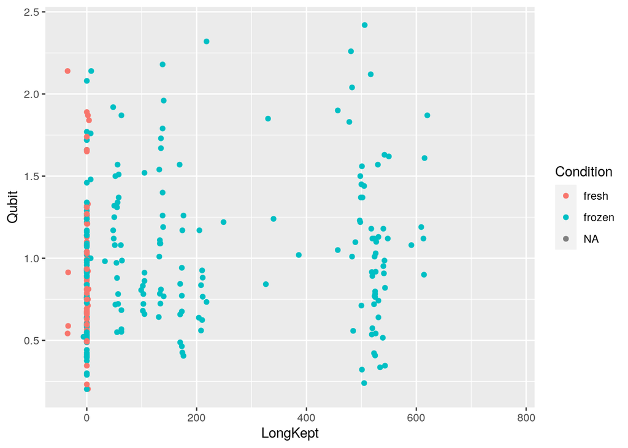

```r
#ggplot(data = Fish, mapping = aes(y = Qubit, x = Condition)) + geom_boxplot(notch = TRUE)
ggplot(data = Fish, mapping = aes(y = Qubit, x = LongKept, color = Condition)) +
  geom_point()
```

[output not shown]

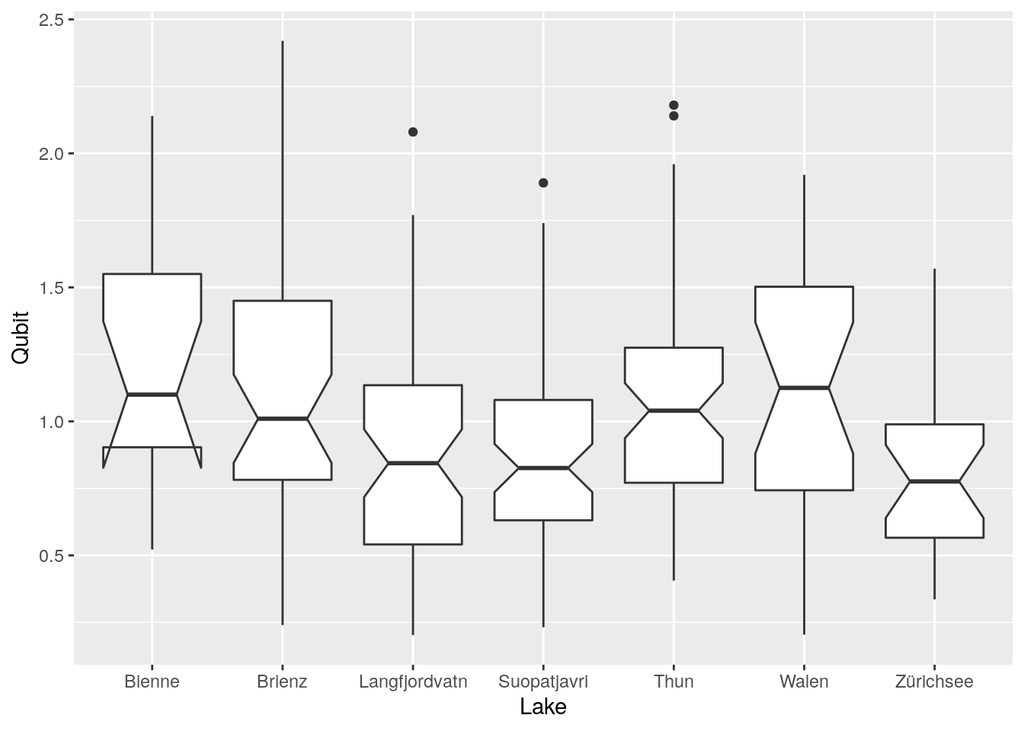

```r
ggplot(data = Fish, mapping = aes(y = Qubit, x = Lake)) + geom_boxplot(notch = TRUE)
```

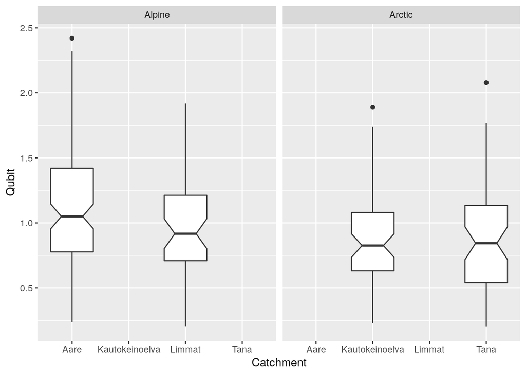

```r
ggplot(data = Fish, mapping = aes(y = Qubit, x = Catchment)) + geom_boxplot(notch = TRUE) +
  facet_wrap(~Region)
```

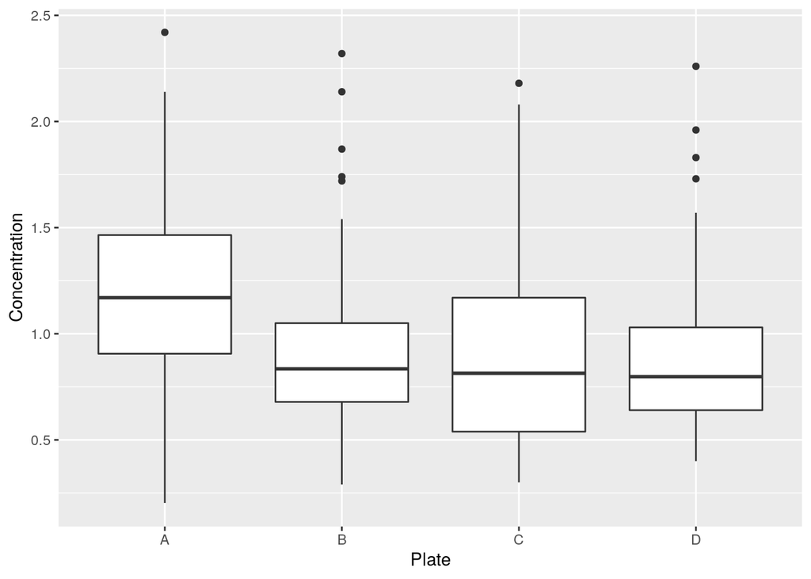

```r
ggplot(Qubit, aes(x=Plate, y=Concentration)) + geom_boxplot()
```

The increase in DNA concentrations in plate A (last one to be processed) may reflect temporal variation in sample processing skills.

We miss the information of what DNA extractions come from fins and what from gills.

## Comparison between Qubit and Bioanalyser estimates of concentration

```r
summary(lm(ng_ul ~ 0 + qubit, data = Smear))
```

```
##
## Call:
## lm(formula = ng_ul ~ 0 + qubit, data = Smear)
##
## Residuals:
##      Min       1Q   Median       3Q      Max
## -0.46754 -0.25338 -0.13479  0.02158  0.83895
##
## Coefficients:
##       Estimate Std. Error t value Pr(>|t|)
## qubit   1.2763     0.1162   10.98 6.71e-07 ***
## ---
## Signif. codes:  0 '***' 0.001 '**' 0.01 '*' 0.05 '.' 0.1 ' ' 1
##
## Residual standard error: 0.443 on 10 degrees of freedom
## Multiple R-squared:  0.9234, Adjusted R-squared:  0.9157
## F-statistic: 120.5 on 1 and 10 DF,  p-value: 6.709e-07
```

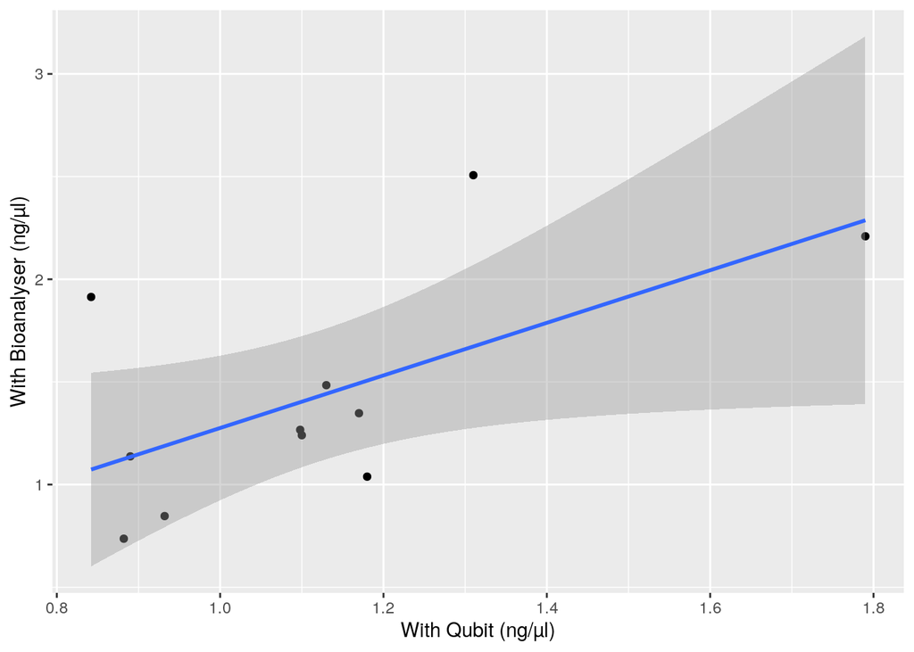

```r
ggplot(data = Smear, mapping = aes(x = qubit, y = ng_ul)) + geom_point() +
  geom_smooth(method = 'lm') + xlab('With Qubit (ng/µl)') + ylab('With Bioanalyser (ng/µl)')
```

Bioanalyser gives on average higher estimates than Qubit. The good thing is that there is a positive linear relationship. What worries me is that dispersion is high. We can suspect Bioanalyser’s measures to be more accurate, but we cannot know. All we have is two measures for 11 samples, and only one in the rest. What these 11 repeated measurements give us is an idea of the uncertainty in concentration. That uncertainty will translate into imbalance of total coverage per sample (see below).

## Pooling

The smear analysis from Bioanalyser contains estimates of molarity (nmole/l) as well as concentration (ng/µl). If all libraries have a similar distribution of fragment sizes, as expected from a similar digestion, ligation and PCR efficiencies, then the relationship between mass and number of fragments should be quite constant across samples. To transform from nmole/l to pmole/µl, I divide by 1000. Then, I obtain the number of fragments per unit of mass, in pmole/ng by dividing molarity (pmole/µl) by concentration (ng/µl).

```r
Smear$pmole_ng <- Smear$nmolePerL / (1000 * Smear$ng_ul)
Avogadro <- 6.02214076e+23
```

Thus, there must be in the order of 1500 milion fragments per ng of DNA. If we succeeded in amplifying a number of loci between 50000 and 100000, it means that on average a locus must be represented by a number of copies between 15000 and 29000.

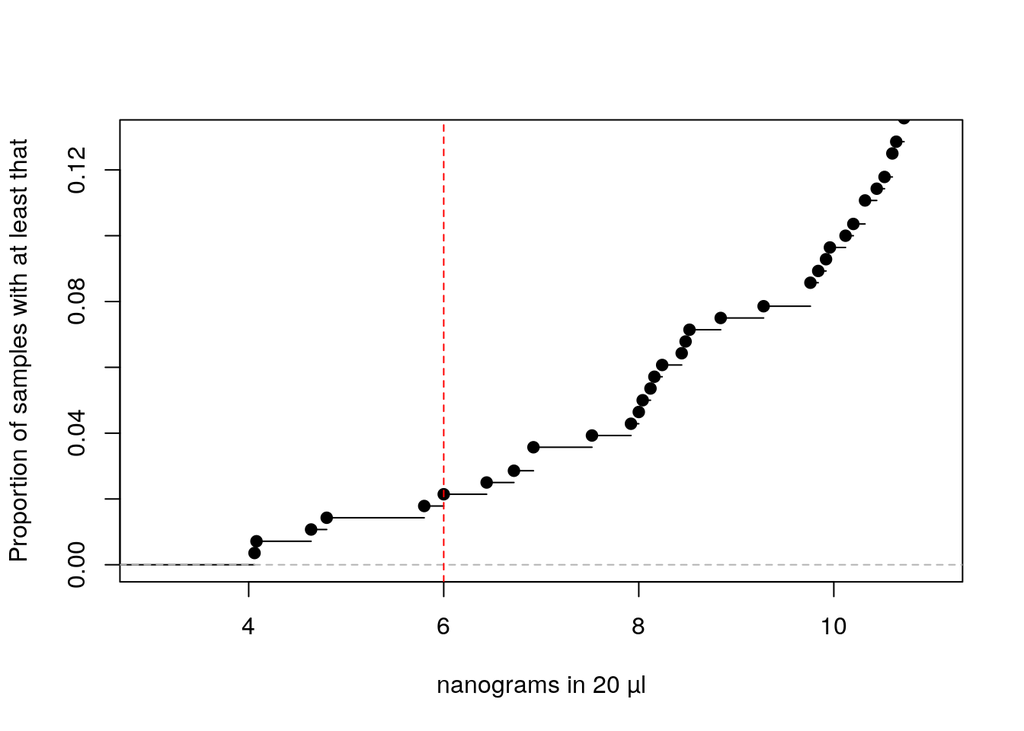

```r
Qubit$ng20 <- Qubit$Concentration * 20
plot(ecdf(Qubit$ng20), main = '', xlab = 'nanograms in 20 µl',
     ylab = 'Proportion of samples with at least that',
     xlim = c(3,11), ylim = c(0, 0.13))
abline(v = 6.0, col = 'red', lty = 2)
```

I think 6.00 ng of DNA per sample should be enough. But keep reading.

## Dispersion

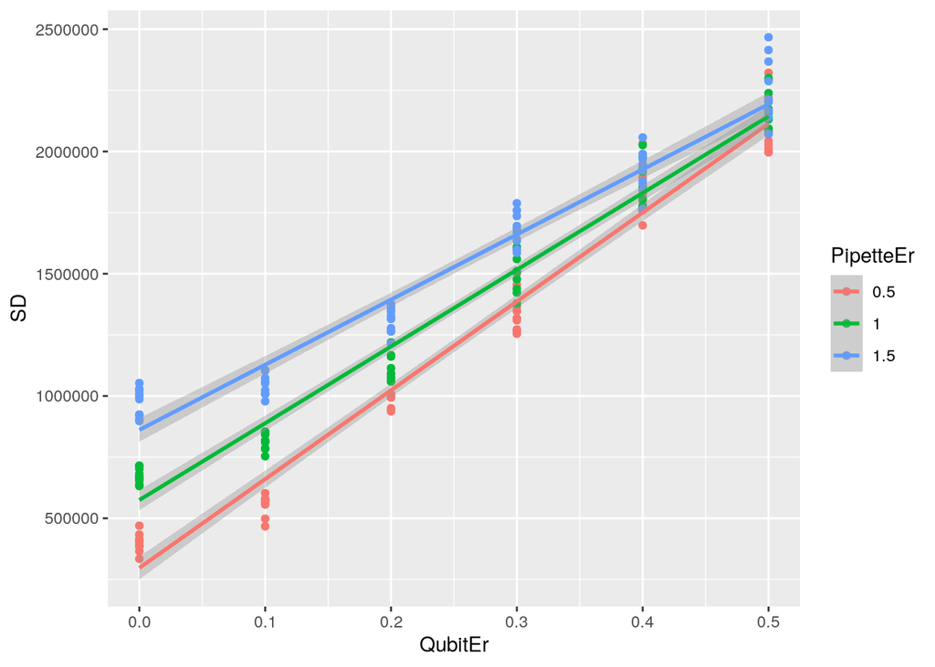

```r
NumSamples <- 280
sequencing <- function(n, ConcMean = 1.0, ConcSD = 0.4, QubitError = 0.25,
                       PipetteError = 1, minConc = 0.1, TargetMass = 6,
                       MaxVolume = 20, Effort = 1.0e+09, reads=FALSE){
  Conc.Real <- rnorm(NumSamples, mean = ConcMean, sd = ConcSD)
  # Require positive real concentrations
  while (any(Conc.Real < minConc)) {
    Conc.Real[Conc.Real < minConc] <- rnorm(sum(Conc.Real < minConc),
                                            mean = ConcMean, sd = ConcSD)
  }
  # Estimated concentrations may be zero, not less
  Conc.Estim <- rnorm(NumSamples, mean = Conc.Real, sd = QubitError)
  Conc.Estim[Conc.Estim <= 0] <- 0
#  while (any(Conc.Estim < minConc)) {
#    Conc.Estim[Conc.Estim < minConc] <- rnorm(sum(Conc.Estim < minConc),
#                                              mean = Conc.Real[Conc.Estim < minConc],
#                                              sd = QubitError)
#  }
  Volume.Estim <- TargetMass / Conc.Estim
  Volume.Real <- rnorm(NumSamples, mean = Volume.Estim, sd = PipetteError)
  # DNA amount is limitting:
  Volume.Real[Volume.Real > MaxVolume] <- MaxVolume
  Volume.Real[Volume.Real <= 0] <- 0
  Mass.Real <- Volume.Real * Conc.Real
  Proportions <- Mass.Real / sum(Mass.Real)
  NumReads <- rmultinom(1, Effort, Proportions)
  ifelse(reads, return(NumReads), return(Proportions))
}

# Empirical mean of standard deviations between Qubit and Bioanalyser measures:
Error1 <- mean(sapply(1:dim(Smear)[1], function(x) sd(c(Smear[x, 'ng_ul'], Smear[x,'qubit']))))

CoverageSD1 <- t(
  sapply(c(rep(0,10),rep(0.1,10),rep(0.2,10),rep(0.3,10),rep(0.4,10),rep(0.5,10)),
         function(x) {
           z <- sequencing(280, QubitError = x, PipetteError = 0.5, reads = TRUE)
           return(c(mean(z), sd(z), x, 0.5))
         })
)
CoverageSD2 <- t(
  sapply(c(rep(0,10),rep(0.1,10),rep(0.2,10),rep(0.3,10),rep(0.4,10),rep(0.5,10)),
         function(x) {
           z <- sequencing(280, QubitError = x, PipetteError = 1.0, reads = TRUE)
           return(c(mean(z), sd(z), x, 1.0))
         })
)
CoverageSD3 <- t(
  sapply(c(rep(0,10),rep(0.1,10),rep(0.2,10),rep(0.3,10),rep(0.4,10),rep(0.5,10)),
         function(x) {
           z <- sequencing(280, QubitError = x, PipetteError = 1.5, reads = TRUE)
           return(c(mean(z), sd(z), x, 1.5))
         })
)
CovSD <- as.data.frame(rbind(CoverageSD1, CoverageSD2, CoverageSD3))
names(CovSD) <- c('Mean','SD','QubitEr','PipetteEr')
CovSD$PipetteEr <- factor(CovSD$PipetteEr)
ggplot(data = CovSD, mapping = aes(x = QubitEr, y = SD, color = PipetteEr)) +
  geom_point() + geom_smooth(method = 'lm')
```

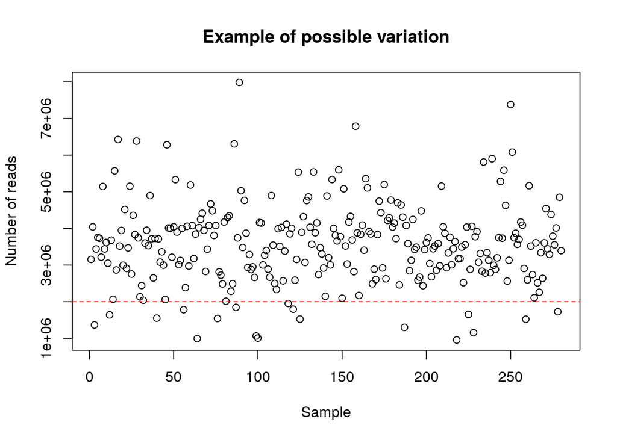

```r
plot(sequencing(280, QubitEr = 0.25, PipetteError = 1.0, reads = TRUE, TargetMass = 10),
     main = 'Example of possible variation',
     xlab = 'Sample', ylab = 'Number of reads')
abline(h = 2.0e+06, col = 'red', lty = 2)
```

These simulations warn us that error in concentration measures and pipetting can be a very important source of variation in total coverage per sample. The average standard deviation between Qubit and Bioanalyser measures, 0.27 may be an overestimate of the true error. And I wish pipetting errors are not above 1 µl.

What is the effect of the targetted mass per sample in the dispersion of coverage?

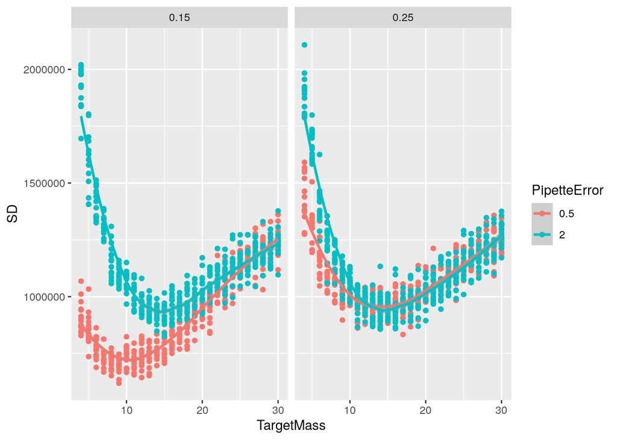

```r
CovMas1 <- t(
  sapply(rep(4:30, each = 15), function(x) {
    z <- sequencing(280, QubitError = 0.15, PipetteError = 0.5, TargetMass = x, reads = TRUE, ConcSD = 0.4)
    return(c(mean(z), sd(z), x, 0.15, 0.5))
  })
)
CovMas2 <- t(
  sapply(rep(4:30, each = 15), function(x) {
    z <- sequencing(280, QubitError = 0.15, PipetteError = 2, TargetMass = x, reads = TRUE, ConcSD = 0.4)
    return(c(mean(z), sd(z), x, 0.15, 2))
  })
)
CovMas3 <- t(
  sapply(rep(4:30, each = 15), function(x) {
    z <- sequencing(280, QubitError = 0.25, PipetteError = 0.5, TargetMass = x, reads = TRUE, ConcSD = 0.4)
    return(c(mean(z), sd(z), x, 0.25, 0.5))
  })
)
CovMas4 <- t(
  sapply(rep(4:30, each = 15), function(x) {
    z <- sequencing(280, QubitError = 0.15, PipetteError = 2, TargetMass = x, reads = TRUE, ConcSD = 0.4)
    return(c(mean(z), sd(z), x, 0.25, 2))
  })
)

CovMass <- as.data.frame(rbind(CovMas1, CovMas2, CovMas3, CovMas4))
names(CovMass) <- c('Mean', 'SD', 'TargetMass', 'QubitError', 'PipetteError')
CovMass$QubitError   <- factor(CovMass$QubitError)
CovMass$PipetteError <- factor(CovMass$PipetteError)

ggplot(data = CovMass, mapping = aes(x = TargetMass, y = SD, color = PipetteError)) +
  geom_point() + geom_smooth() + facet_wrap(~QubitError)
```

## Conclusion

Before realising of this, I would have chosen 6 ng per sample. Now, I realise it is safer to use 10 ng per sample, even if the number of samples that do not reach that amount is larger. Below I write down the table with the reccommended volumes per sample.

```r
MaxVolume <- 25  # I know it's less, but this way we can judge if we need to add the whole amount or not.
Amount <- 10.00 # ng
Qubit$Volume <- pmin(MaxVolume, Amount / Qubit$Concentration)
Qubit$Amount <- Qubit$Volume * Qubit$Concentration
write.table(Qubit, 'Pooling.tsv', sep='\t', quote = FALSE, row.names = FALSE)
```